# Course Notes 2

January 12, 2016

## Guidelines for good plots

## High data density

- Guideline 1: **Aim for high data density.**

**Data to ink ratio**:

Ratio of "ink" providing information to all ink

## High data density

- Guideline 1: **Aim for high data density.**

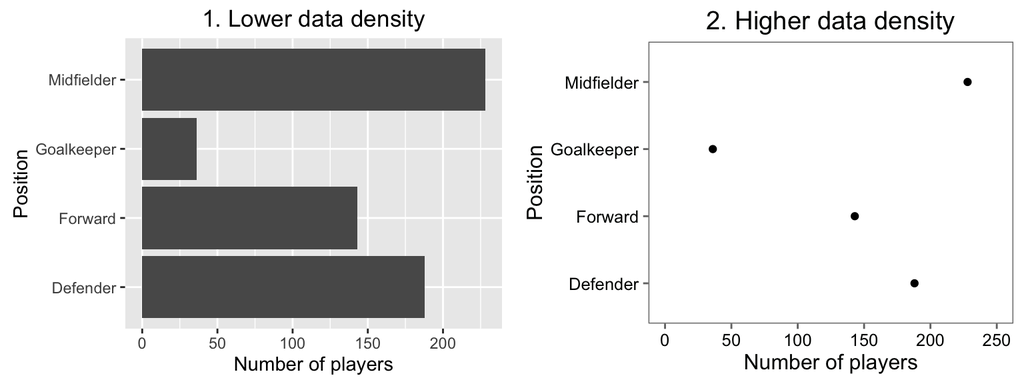

## High data density

- Guideline 1: **Aim for high data density.**

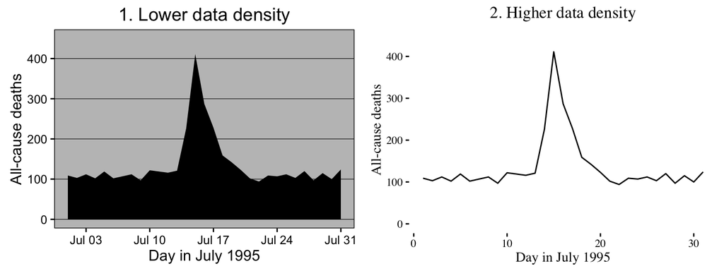

## Meaningful labels

- Guideline 2: **Use clear, meaningful labels.**

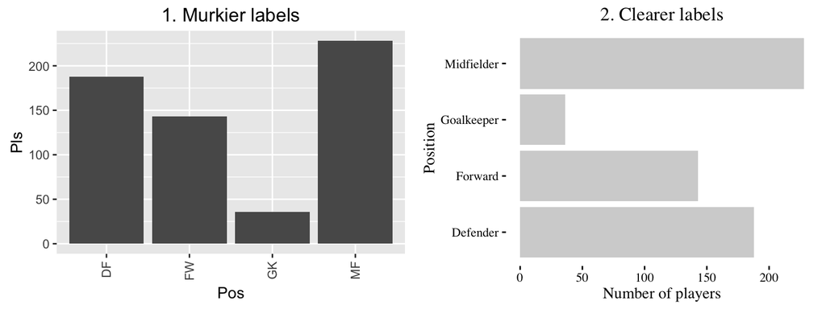

## References

- Guideline 3: **Provide useful references.**

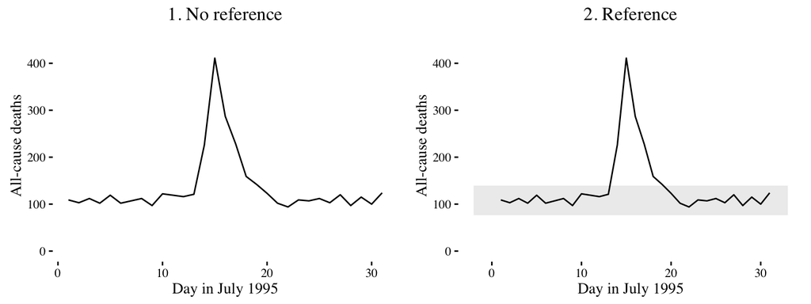

## References

- Guideline 3: **Provide useful references.**

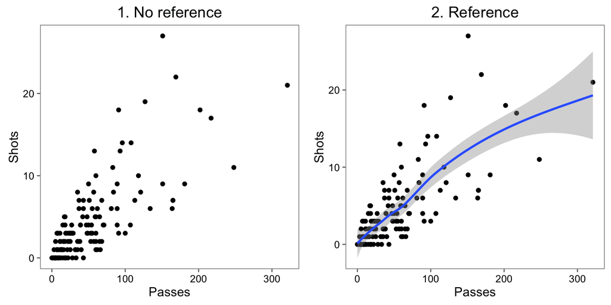

## Interesting aspects

- Guideline 3: **Highlight interesting aspects.**

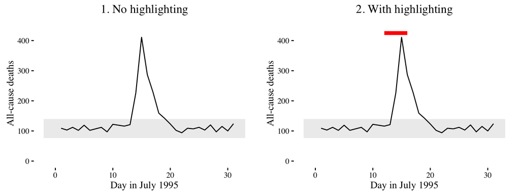

## Interesting aspects

- Guideline 3: **Highlight interesting aspects.**

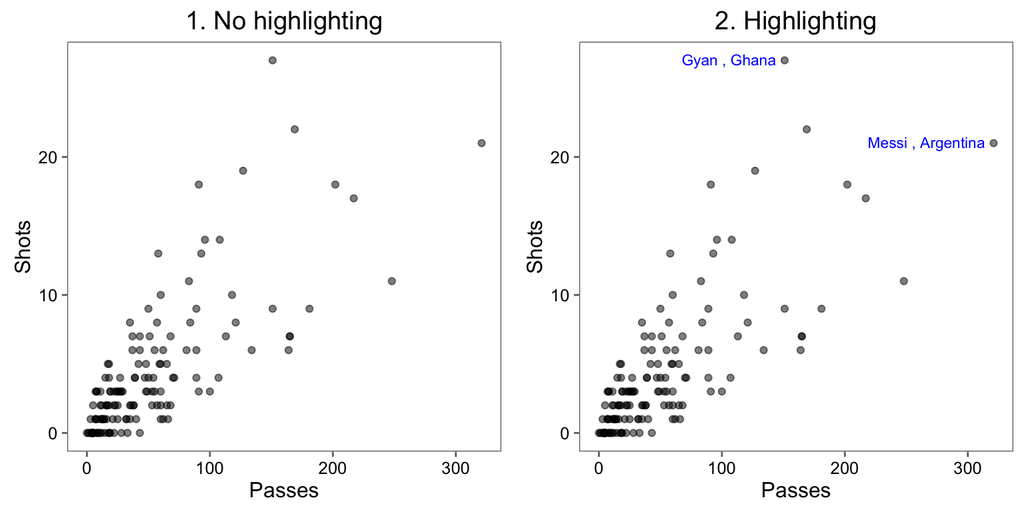

## Order

- Guideline 4: **Make order meaningful.**

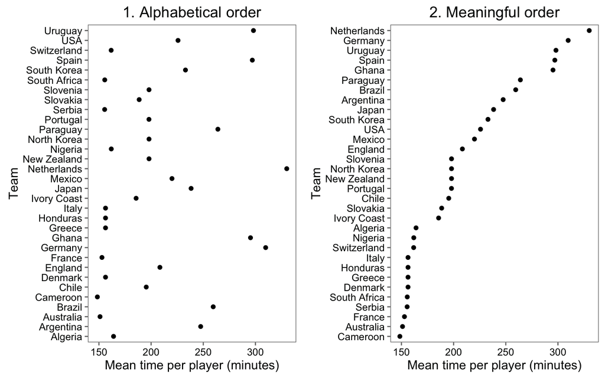

## Small multiples

- Guideline 5: **When possible, use small multiples.**
- Many small plots showing the same thing for different facets
- Same x- and y-axes
- Limit axis annotation

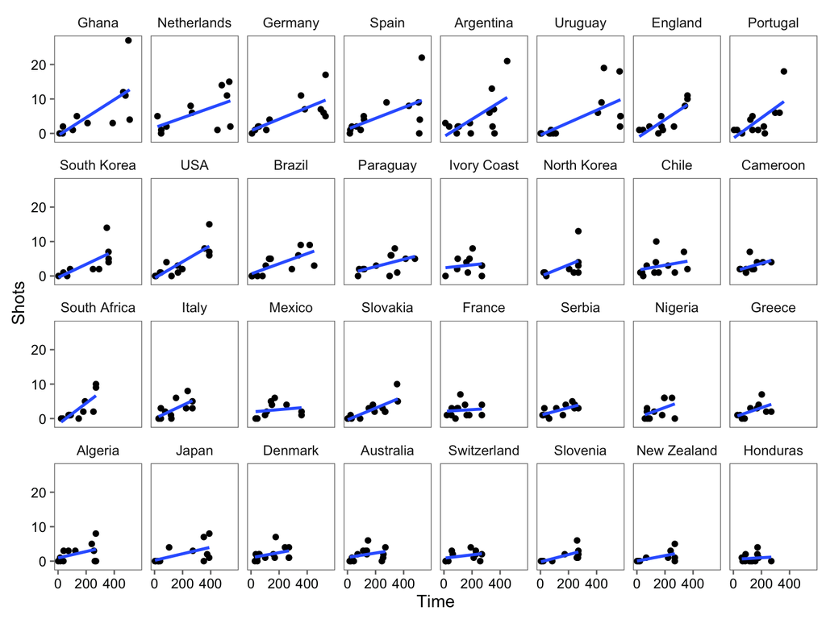

## Learn more

To find out more about how to make effective graphics, check out:

- Edward Tufte
- Howard Wainer
- Stephen Few
- Nathan Yau

## ggplot2

## `ggplot` conventions

Basic idea:

You'll create an object of the `ggplot` class. Then, you'll "add on" to customize it, using `+`.

*Note*: To avoid errors, end lines with `+`, don't start lines with it.

## `ggplot` conventions

Code conventions are different for `ggplot` than for base R graphics.

First, you need to initialize a ggplot object using the `ggplot()` function. You can use this to specify the dataframe and map variables in your data to `x` and `y` components of the graph.

```r
first_graph <- ggplot(chic_july,
                      aes(x = date, y = death))
```

This is not enough to plot something– you will need to add one or more `geom` to plot.

## `ggplot` conventions

To add a scatterplot, you can add a `geom_point()`:

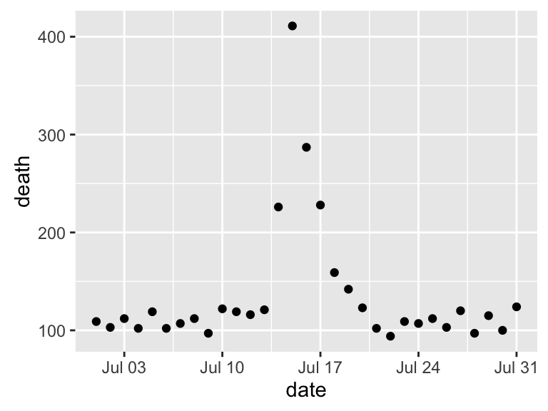

```r
first_graph + geom_point()
```

## `ggplot` conventions

Note that there are a few ways you could have done this:

Without saving the plot as an object:

```r
ggplot(chic_july, aes(x = date, y = death)) +
        geom_point()
```

Saving as an object, then save on the added geom, then print:

```r
first_graph <- ggplot(chic_july,
                      aes(x = date, y = death))
first_graph <- first_graph + geom_point()
first_graph
```

## `ggplot` conventions

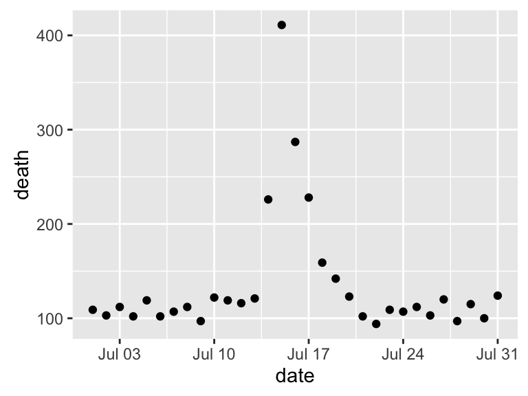

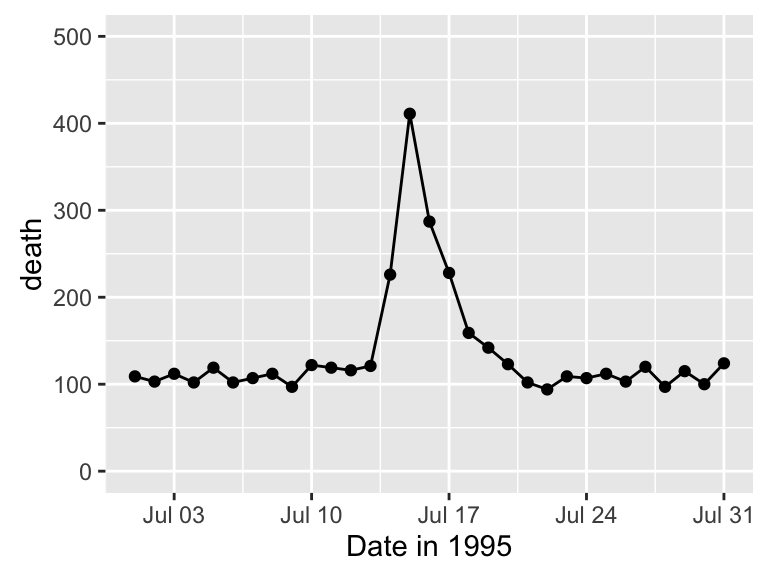

```r
first_graph <- ggplot(chic_july,
                      aes(x = date, y = death))
first_graph <- first_graph + geom_point()

first_graph
first_graph + geom_line() +
        xlab("Date in 1995") +
        ylim(0, 500)
```

## Using ggplot

## Initializing the object

Use the following conventions to initialize a ggplot object:

```r
## Pseudo-code, will not run
[object name] <- ggplot([dataframe],
                        aes(x = [x variable],
                            y = [y variable]))
```

## Adding geoms

Now you can add one or more `geom` to the object to create a plot. Here are some common ones:

- `geom_point()`
- `geom_line()`, `geom_segment()`
- `geom_path()`, `geom_polygon()`
- `geom_histogram()`
- `geom_abline()`, `geom_hline()`, `geom_vline()`
- `geom_boxplot()`
- `geom_smooth()`, `geom_text()`

## Adding geoms

For example:

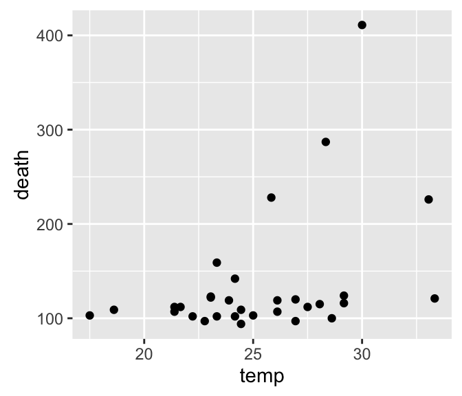

```r
ggplot(chic_july, aes(x = temp, y = death)) +
        geom_point()
```

## Adding geoms

For example:

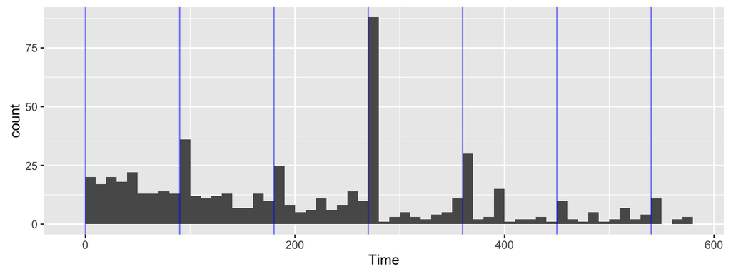

```r
ggplot(worldcup, aes(x = Time)) +
        geom_histogram(binwidth = 10) +
        geom_vline(xintercept = 90 * 0:6,
                   color = "blue", alpha = 0.5)
```

## Adding geoms

Common options for geoms include:

- `color` / `colour`
- `size`
- `alpha` (transparency)

## Adding geoms

Geom options can either be **constant** (e.g., all points are red), or can be **mapped** to a certain characteristic of the data:

```r
a <- ggplot(chic_july, aes(x = date, y = death))  +
        geom_point(color = "red")

chic_july$high_temp <- chic_july$temp > 28
b <- ggplot(chic_july, aes(x = date, y = death,
                      color = high_temp))  +
        geom_point()
```

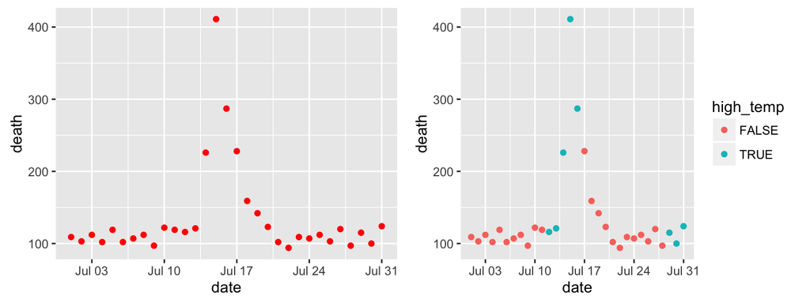

```r
grid.arrange(a, b, ncol = 2)
```

## Data density

Using themes: You can change the "background" elements to a plot by changing the theme.

The `ggthemes` packages has some excellent ones to help reduce "non-data ink".

## Data density

For example:

```r
chic_plot <- ggplot(chic_july,
                    aes(x = date, y = death))  +
        geom_point(color = "red")
```

## Themes

Stephen Few theme:

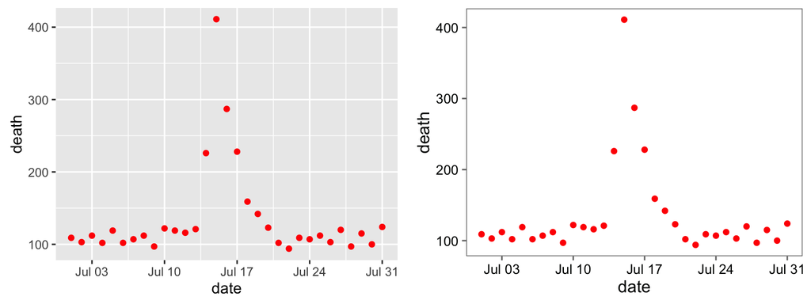

```r
a <- chic_plot
b <- chic_plot + theme_few()
grid.arrange(a, b, ncol = 2)
```

## Themes

Edward Tufte theme:

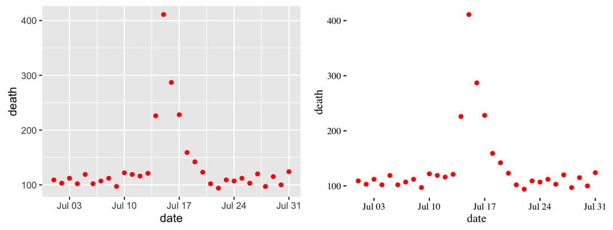

```r
a <- chic_plot
b <- chic_plot + theme_tufte()
grid.arrange(a, b, ncol = 2)
```

## Themes

Black-and-white theme:

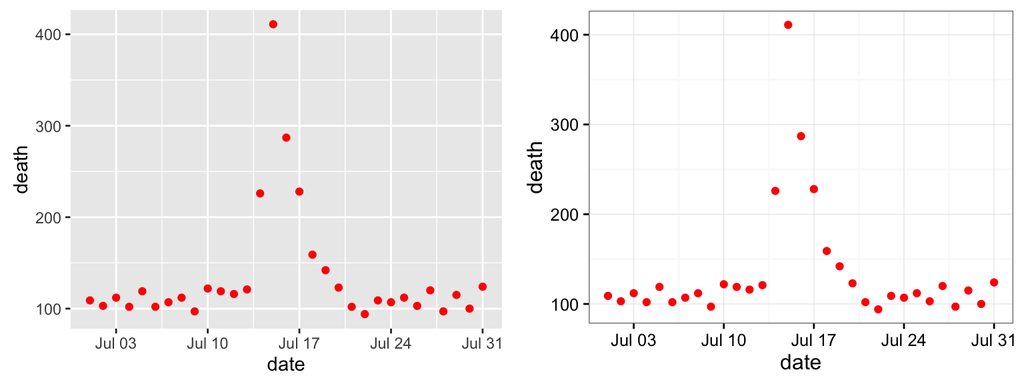

```r
a <- chic_plot
b <- chic_plot + theme_bw()
grid.arrange(a, b, ncol = 2)
```

## Themes

Excel theme:

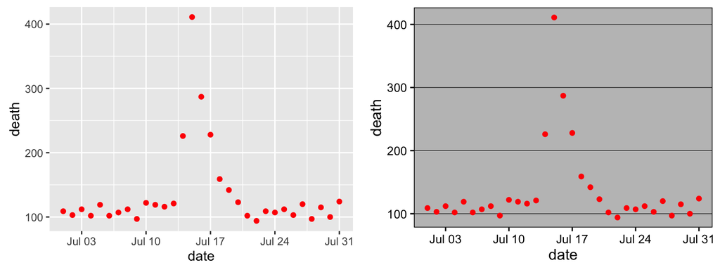

```r
a <- chic_plot
b <- chic_plot + theme_excel()
grid.arrange(a, b, ncol = 2)
```

## Highlighting

One helpful way to annotate is with text, using `geom_text()`:

```r
hottest_day <- chic_july[which.max(chic_july$temp),]
hottest_day
```

```
##            date time year month doy      dow death cvd resp     temp
## 3116 1995-07-13 3116 1995     7 194 Thursday   121  42   10 33.33333
##        dptp  rhum     pm10       o3 high_temp
## 3116 76.375 57.25 90.36365 57.01744      TRUE
```

## Highlighting

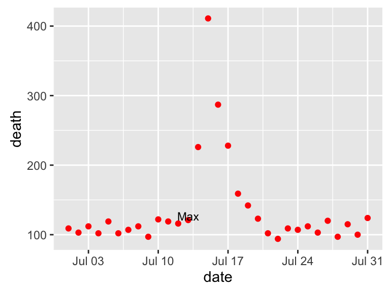

```r
chic_plot + geom_text(data = hottest_day,
                      label = "Max",
                      size = 3, hjust = 0.5, vjust = 0)
```

## Highlighting

You can also use lines to highlight:

```r
chic_july <- subset(chic, month == 7 & year == 1995)
hw <- data.frame(date = c(as.Date("1995-07-12"),
                          as.Date("1995-07-16")),
                 death = c(425, 425))

b <- chic_plot +
        geom_line(aes(x = date, y = death),
                  data = hw[1:2, ],
                  size = 2)
```

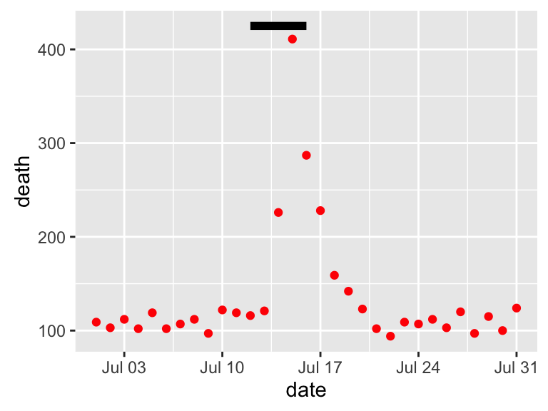

```r
b
```

## Small multiples

You can use the facet functions to create small multiples. This separates the graph into several small graphs, one for each level of a factor.

- `facet_grid()`
- `facet_wrap()`

## Small multiples

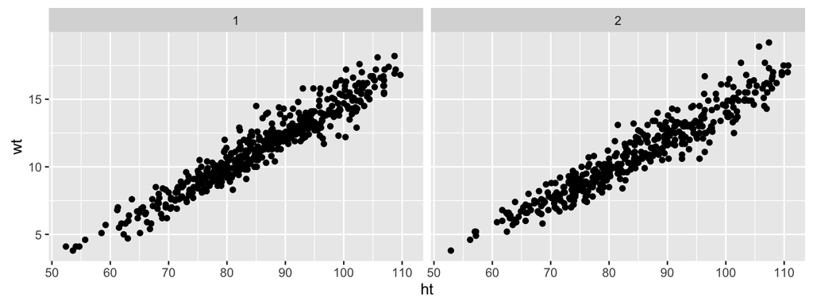

```r
ggplot(nepali, aes(ht, wt)) +
        geom_point() +
        facet_grid(. ~ sex)
```

## Small multiples

Conventions for `facet_grid`:

```r
## Note: This is pseudocode and won't run.
facet_grid([factor for rows] ~ [factor for columns])
```

```r
## Note: This is pseudocode and won't run.
facet_wrap(~ [factor for faceting], ncol = [# of columns])
```

## Small multiples

Re-naming and re-ordering factors:

Often, when you do faceting, you'll want to re-name your factors levels or re-order them.

For this, you'll need to use the `factor()` function on the original vector:

```r
nepali$sex <- factor(nepali$sex,
                     levels = c(1, 2),
                     labels = c("Male", "Female"))
```

## Small multiples

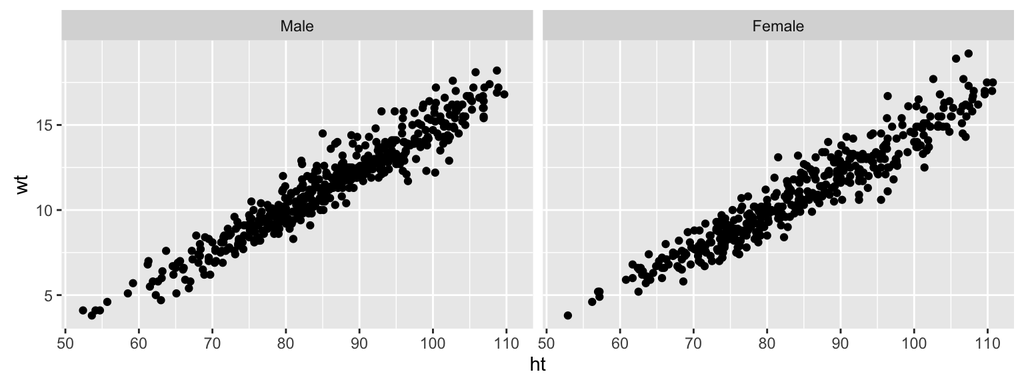

```r
ggplot(nepali, aes(ht, wt)) +
        geom_point() +
        facet_grid(. ~ sex)
```

## Small multiples

You can do the same idea to re-order a factor:

```r
nepali$sex <- factor(nepali$sex,
                     levels = c("Female", "Male"))
```

## Small multiples

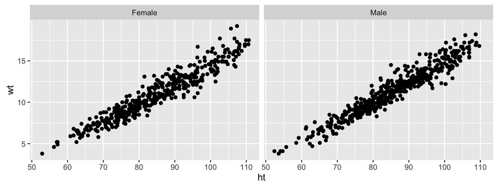

```r
ggplot(nepali, aes(ht, wt)) +
        geom_point() +
        facet_grid(. ~ sex)
```

## Annotation

You can use the following functions for main and axis titles:

- `ggtitle()`
- `xlab()`
- `ylab()`

You can also use the "convenience" functions for limits for x- and y-axes:

- `xlim()`
- `ylim()`

## Excellent references

- R Graphics Cookbook
- Google images
- [ggplot](https://www.rstudio.com/wp-content/uploads/2015/08/ggplot2-cheatsheet.pdf)

Other "cheatsheets":

- [R Markdown](https://www.rstudio.com/wp-content/uploads/2015/02/rmarkdown-cheatsheet.pdf)
- [Data wrangling](https://www.rstudio.com/wp-content/uploads/2015/02/data-wrangling-cheatsheet.pdf)